## **Western ringtail possum**

### *Pseudocheirus occidentalis*

### Blamed on foxes

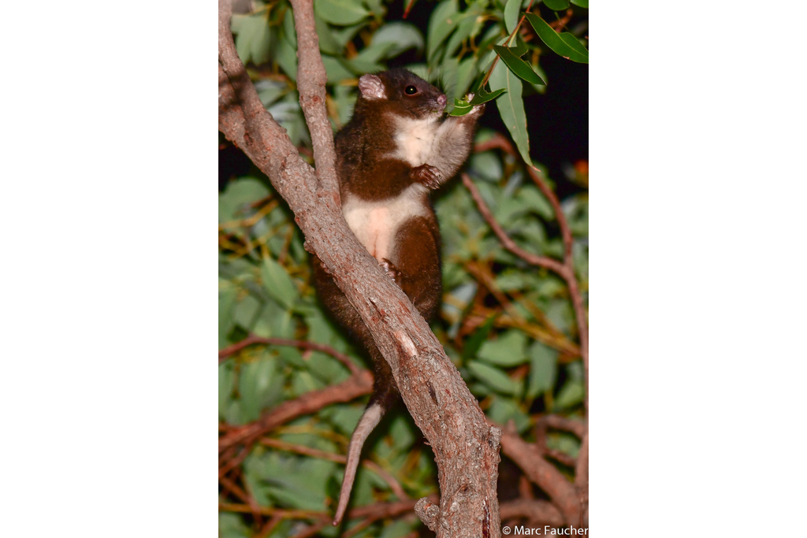

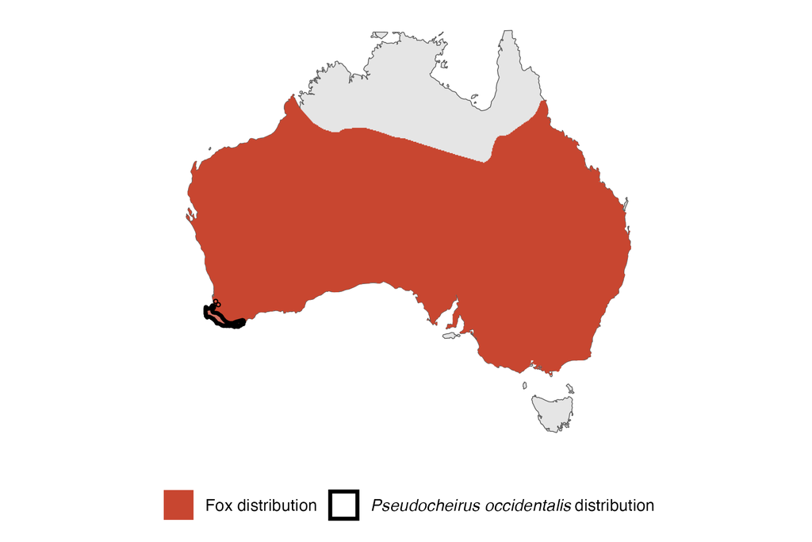

IUCN status: **Critically Endangered**

EPBC Predator Threat Rating: **Very high/Extreme**

IUCN claim: *“Translocation experiments in the past and other data demonstrate that Red Foxes and feral Cats are major threats”*

### Studies in support

Foxes hunt locally-born possums (Jones et al. 1994; Wayne et al. 2005; Grimm & De Tores 2009) and they hunted 9 of 68 reintroduced possums (Clarke 2011).

### Studies not in support

Decades of poison-baiting aimed at foxes did not prevent population decline (Wayne et al. 2017).

### Is the threat claim evidence-based?

No studies were found linking foxes to Western ringtail possum population trends.

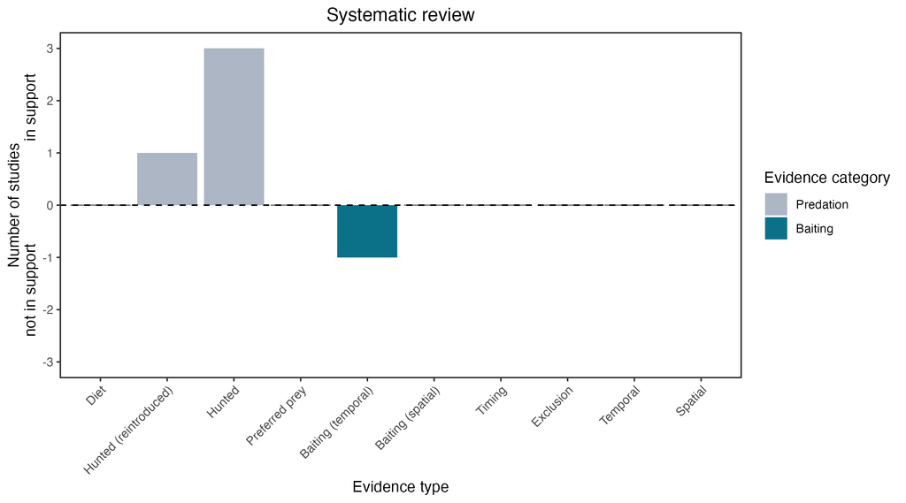

**Evidence linking *Pseudocheirus occidentalis* to foxes.** Systematic review of evidence for an association between *Pseudocheirus occidentalis* and foxes. Positive studies are in support of the hypothesis that *foxes* contribute to the decline of Pseudocheirus occidentalis, negative studies are not in support. Predation studies include studies documenting hunting or scavenging; baiting studies are associations between poison baiting and threatened mammal abundance where information on predator abundance is not provided; population studies are associations between threatened mammal and predator abundance. Gold borders indicate studies that meet qualities of scientific rigour. See methods section in Wallach and Lundgren 2025 for details on evidence categories.

### References

Clarke, J.R., 2011. Translocation outcomes for the western ringtail possum (Pseudocheirus occidentalis) in the presence of the common brushtail possum (Trichosurus vulpecula): health, survivorship and habitat use. Doctoral dissertation, Murdoch University.

EPBC. (2015) Threat Abatement Plan for Predation by Feral Cats. Environment Protection and Biodiversity Conservation Act 1999, Department of Environment, Government of Australia. (Table A1).

Grimm, H.L. and De Tores, P.J., 2009. Some aspects of the biology of the common brushtail possum, Trichosurus vulpecula, and the threatened western ringtail possum, Pseudocheirus occidentalis, in a pine plantation scheduled for harvesting and in adjacent turat and peppermint woodland near Busselton, Western Australia. Government of Western Australia, Perth.

IUCN Red List. https://www.iucnredlist.org/ Accessed June 2023

Jones, B.A., How, R.A. and Kitchener, D.J., 1994. A field study of Pseudocheirus occidentalis (Marsupialia: Petauridae) II. Population studies. Wildlife Research, 21(2), pp.189-201.

Wallach A.D., Lundgren E.J. (2025) Review of evidence that foxes and cats cause extinctions of Australia’s endemic mammals. BioScience. DOI: 10.1093/biosci/biaf046

Wayne, A.F., Maxwell, M.A., Ward, C.G., Wayne, J.C., Vellios, C.V. and Wilson, I.J., 2017. Recoveries and cascading declines of native mammals associated with control of an introduced predator. Journal of Mammalogy, 98(2), pp.489-501.

Wayne, A.F., Rooney, J.F., Ward, C.G., Vellios, C.V. and Lindenmayer, D.B., 2005. The life history of Pseudocheirus occidentalis (Pseudocheiridae) in the jarrah forest of south-western Australia. Australian Journal of Zoology, 53(5), pp.325-337.